# day 3

このノートブックの実行例はこちら(HTML版)で確認できます

## 0. はじめに

ページ上部のメニューバーにある **Kernel** メニューをクリックし、プルダウンメニューから [**Change Kernel ...**] を選び、**gssm2023:Python** を選択してください。

[figure not shown]

ノートブック上部の右隅に表示されたカーネル名が **gssm2023:Python** になっていることを確認してください。

[figure not shown]

## 1. テキスト解析 (2)

### 1.0 事前準備 (関数の定義)

以下のセルを**修正せず**に実行してください

```python
import warnings
warnings.simplefilter('ignore')

import random
import numpy as np

# 乱数を固定する
seed = 42
random.seed(seed)
np.random.seed(seed)

# ワードクラウドを描画する
def plot_wordcloud(word_str, width=6, height=4):

    # 必要ライブラリのインポート
    import matplotlib.pyplot as plt

    # ノートブック中にプロットするマジックコマンド
    %matplotlib inline

    # プロットの準備
    fig = plt.figure(figsize=(width, height))
    ax = fig.add_subplot(1, 1, 1)

    # 指定したプロット位置(ax)にワードクラウドを描画する
    plot_wordcloud_ax(ax, word_str)

    # プロットの仕上げ
    plt.axis("off")
    plt.tight_layout()
    plt.show()

# 指定したプロット位置(ax)にワードクラウドを描画する
def plot_wordcloud_ax(ax, word_str):

    # フォントパスを取得する
    font_path = !find ${HOME} -name "ipaexg.ttf"

    # 必要ライブラリのインポート
    import wordcloud

    # ワードクラウドを作成する
    wc = wordcloud.WordCloud(
        background_color='white',
        font_path=font_path[0],
        max_font_size=100)

    # ワードクラウドを描画する
    img = wc.generate(word_str)
    ax.imshow(img, interpolation='bilinear')


# トピックモデルによるワードクラウドを描画する
def plot_topic_model(lda, feature_names, n_top_words=20, width=10, height=4):

    # フォントパスを取得する
    font_path = !find ${HOME} -name "ipaexg.ttf"

    # 必要ライブラリのインポート
    import matplotlib.pyplot as plt
    import wordcloud

    # ノートブック中にプロットするマジックコマンド
    %matplotlib inline

    fig = plt.figure(figsize=(width, height))

    # トピックごとのループ
    for topic_idx, topic in enumerate(lda.components_):

        # トピック中で出現確率の高い頻に単語をソートし,
        # ワードクラウドに描画するためテキストを生成する
        sorted_text = ' '.join([feature_names[i] for i in topic.argsort()[:-n_top_words-1:-1]])

        # ワードクラウドを作成する
        wc = wordcloud.WordCloud(
            background_color='white',
            font_path=font_path[0],
            max_font_size=100)

        # プロット位置(ax)を選ぶ
        ax = fig.add_subplot(2, 3, topic_idx + 1)

        # ワードクラウドを描画する
        img = wc.generate(sorted_text)
        ax.imshow(img, interpolation='bilinear')
        ax.set_title(f"Topic # {topic_idx+1}:")

    # プロットの仕上げ
    plt.tight_layout()
    plt.show()


# 共起ネットワーク図を描画する (抽出語-抽出語用)
def plot_cooccur_network(df, word_counts, cutoff, width=8, height=8):

    # 必要ライブラリのインポート
    import matplotlib.pyplot as plt
    import japanize_matplotlib

    # プロットの準備
    plt.figure(figsize=(width, height))
    fig = plt.figure(figsize=(width, height))

    # プロット位置(ax)を選ぶ
    ax = fig.add_subplot(1, 1, 1)

    # 指定したプロット位置(ax)に共起ネットワーク図を描画する
    plot_cooccur_network_ax(ax, df, word_counts, cutoff)

    # プロットの仕上げ
    plt.axis("off")
    plt.show()

# 指定したプロット位置(ax)に共起ネットワーク図を描画する
def plot_cooccur_network_ax(ax, df, word_counts, cutoff):

    # 必要ライブラリのインポート
    import numpy as np
    import networkx as nx
    from networkx.algorithms import community
    from networkx.drawing.nx_agraph import graphviz_layout
    import matplotlib.pyplot as plt
    import japanize_matplotlib

    # ノートブック中にプロットするマジックコマンド
    %matplotlib inline

    # 共起行列の中身(numpy行列)を取り出す
    Xc = df.values

    # 共起行列中の最大値を求める
    Xc_max = Xc.max()

    # プロットする単語リストを取得する
    words = df.columns

    # プロットする単語の出現頻度の最大値を求める (正規化用)
    count_max = word_counts.max()

    weights_w, weights_c = [], []

    # 共起行列の要素ごとのループ (値がゼロの要素はスキップ)
    for i, j in zip(*Xc.nonzero()):
        # 対角行列でかつ値がしきい値を超えるものを保持する
        if i < j and Xc[i,j] > cutoff:
            # ノード: 一方の単語とノードの大きさ(正規化した出現頻度)を保持する
            weights_w.append((words[i], {'weight': word_counts[i] / count_max}))
            # ノード: 他方の単語とノードの大きさ(正規化した出現頻度)を保持する
            weights_w.append((words[j], {'weight': word_counts[j] / count_max}))
            # エッジ: 両端の単語を結ぶエッジの太さ(正規化した共起行列の値)を保持する
            weights_c.append((words[i], words[j], Xc[i,j] / Xc_max))

    # グラフの作成
    G = nx.Graph()
    G.add_nodes_from(weights_w)
    G.add_weighted_edges_from(weights_c)
    G.remove_nodes_from(list(nx.isolates(G)))
    # G = nx.minimum_spanning_tree(G)
    # pos = nx.spring_layout(G, k=0.3)
    pos = graphviz_layout(G, prog='neato', args='-Goverlap="scalexy" -Gsep="+6" -Gnodesep=0.8 -Gsplines="polyline" -GpackMode="graph" -Gstart={}'.format(43))

    # プロット用にノートとエッジの重みをリストに変換する
    weights_n = np.array(list(nx.get_node_attributes(G, 'weight').values()))
    weights_e = np.array(list(nx.get_edge_attributes(G, 'weight').values()))

    # サブグラフの検出
    communities = community.greedy_modularity_communities(G)
    color_map = []
    for node in G:
        for i, c in enumerate(communities):
            if node in c:
                color_map.append(i)

    # グラフの描画
    nx.draw_networkx_nodes(G, pos, node_color=color_map, alpha=0.7, cmap=plt.cm.Set2, node_size=5000 * weights_n, ax=ax)
    nx.draw_networkx_edges(G, pos, edge_color='gray', edge_cmap=plt.cm.Blues, alpha=0.7, width=3 * weights_e, ax=ax)
    nx.draw_networkx_labels(G, pos, font_family='IPAexGothic', ax=ax)
    # ax.axis('off')


# 共起ネットワークを描画する (外部変数-抽出語用)
def plot_attrs_network(df, attr_counts, word_counts, cutoff, width=8, height=8):

    # 必要ライブラリのインポート
    import numpy as np
    import networkx as nx
    import matplotlib.pyplot as plt
    import japanize_matplotlib
    from networkx.drawing.nx_agraph import graphviz_layout

    # ノートブック中にプロットするマジックコマンド
    %matplotlib inline

    # 共起行列の中身(numpy行列)を取り出す
    Xc = df.values

    # 共起行列中の最大値を求める
    Xc_max = Xc.max()

    # プロットする属性(外部変数等)リストを取得する
    attrs = list(df.index)

    # プロットする属性(外部変数等)の最大数を求める (正規化用)
    attr_count_max = attr_counts.max()

    # プロットする単語リストを取得する
    words = list(df.columns)

    # プロットする単語の出現頻度の最大値を求める (正規化用)
    word_count_max = word_counts.max()

    weights_n, weights_c = [], []

    # 共起行列の要素ごとのループ
    for i, j in zip(*Xc.nonzero()):
        # 値がしきい値を超えるものを保持する (値がゼロの要素はスキップ)
        if Xc[i,j] > cutoff:
            # ノード: 属性(外部変数等)とノードの大きさ(正規化した属性数)を保持する
            weights_n.append((attrs[i], {'weight': attr_counts[i] / attr_count_max, 'type': 'attr'}))
            # ノード: 単語とノードの大きさ(正規化した出現頻度)を保持する
            weights_n.append((words[j], {'weight': word_counts[j] / word_count_max, 'type': 'word'}))
            # エッジ: 属性(外部変数等)と単語を結ぶエッジの太さ(正規化した共起行列の値)を保持する
            weights_c.append((attrs[i], words[j], Xc[i,j] / Xc_max))
```

```python
    # プロットの準備
    plt.figure(figsize=(width, height))

    # グラフの作成
    G = nx.Graph()
    G.add_nodes_from(weights_n)
    G.add_weighted_edges_from(weights_c)
    G.remove_nodes_from(list(nx.isolates(G)))
    # G = nx.minimum_spanning_tree(G)
    # pos = nx.spring_layout(G, k=0.3)
    pos = graphviz_layout(G, prog='neato', args='-Goverlap="scalexy" -Gsep="+6" -Gnodesep=0.8 -Gsplines="polyline" -GpackMode="graph" -Gstart={}'.format(43))

    # プロット用にノートとエッジの重みをリストに変換する
    nodelist_a = [node for node in G.nodes if G.nodes[node]['type'] == 'attr']
    nodelist_w = [node for node in G.nodes if G.nodes[node]['type'] == 'word']
    weights_a = np.array([G.nodes[node]['weight'] for node in G.nodes if G.nodes[node]['type'] == 'attr'])
    weights_w = np.array([G.nodes[node]['weight'] for node in G.nodes if G.nodes[node]['type'] == 'word'])
    weights_e = np.array(list(nx.get_edge_attributes(G, 'weight').values()))

    # 属性と単語を色分けする
    color_map = []
    for node in G:
        if G.nodes[node]['type'] == 'word':
            color_map.append(G.degree(node)+3)   # "+3"はカラーマップをシフトする調整値

    # グラフの描画
    nx.draw_networkx_nodes(G, pos, node_color='lightsalmon', alpha=0.7, cmap=plt.cm.Set2, node_size=1000 * weights_a, nodelist=nodelist_a, node_shape='s')
    nx.draw_networkx_nodes(G, pos, node_color=color_map, alpha=0.7, cmap=plt.cm.Set2, node_size=5000 * weights_w, nodelist=nodelist_w)
    nx.draw_networkx_edges(G, pos, edge_color='gray', edge_cmap=plt.cm.Blues, alpha=0.7, width=3 * weights_e)
    nx.draw_networkx_labels(G, pos, font_family='IPAexGothic')

    # プロットの仕上げ
    plt.axis("off")
    plt.show()


# 係り受けによる共起ネットワークを描画する
def plot_dependency_network(df, word_counts, cutoff, width=8, height=8):

    # 必要ライブラリのインポート
    import numpy as np
    import networkx as nx
    from networkx.algorithms import community
    import matplotlib.pyplot as plt
    import japanize_matplotlib
    from networkx.drawing.nx_agraph import graphviz_layout

    # ノートブック中にプロットするマジックコマンド
    %matplotlib inline

    # 共起行列の中身(numpy行列)を取り出す
    Xc = df.values

    # 共起行列中の最大値を求める
    Xc_max = Xc.max()

    # プロットする単語リストを取得する
    words = df.columns

    # プロットする単語の出現頻度の最大値を求める (正規化用)
    count_max = word_counts.max()

    weights_w, weights_c = [], []

    # 共起行列の要素ごとのループ
    for i, j in zip(*Xc.nonzero()):
        # 対角行列でかつ値がしきい値を超えるものを保持する (値がゼロの要素はスキップ)
        if i != j and Xc[i,j] > cutoff:
            # ノード: 一方の単語とノードの大きさ(正規化した出現頻度)を保持する
            weights_w.append((words[i], {'weight': word_counts[i] / count_max}))
            # ノード: 他方の単語とノードの大きさ(正規化した出現頻度)を保持する
            weights_w.append((words[j], {'weight': word_counts[j] / count_max}))
            # エッジ: 両端の単語を結ぶエッジの太さ(正規化した共起行列の値)を保持する
            weights_c.append((words[i], words[j], Xc[i,j] / Xc_max))

    # プロットの準備
    plt.figure(figsize=(width, height))

    # グラフの作成
    G = nx.DiGraph()
    G.add_nodes_from(weights_w)
    G.add_weighted_edges_from(weights_c)
    G.remove_nodes_from(list(nx.isolates(G)))
    # G = nx.minimum_spanning_tree(G)
    # pos = nx.spring_layout(G, k=0.3)
    pos = graphviz_layout(G, prog='neato', args='-Goverlap="scalexy" -Gsep="+6" -Gnodesep=0.8 -Gsplines="polyline" -GpackMode="graph" -Gstart={}'.format(43))

    # プロット用にノートとエッジの重みをリストに変換する
    weights_n = np.array(list(nx.get_node_attributes(G, 'weight').values()))
    weights_e = np.array(list(nx.get_edge_attributes(G, 'weight').values()))

    # サブグラフの検出
    communities = community.greedy_modularity_communities(G)
    color_map = []
    for node in G:
        for i, c in enumerate(communities):
            if node in c:
                color_map.append(i)

    # グラフの描画
    nx.draw_networkx_nodes(G, pos, node_color=color_map, alpha=0.7, cmap=plt.cm.Set2, node_size=5000 * weights_n)
    nx.draw_networkx_edges(G, pos, edge_color='gray', edge_cmap=plt.cm.Blues, alpha=0.7, width=3 * weights_e)
    nx.draw_networkx_labels(G, pos, font_family='IPAexGothic')

    # プロットの仕上げ
    plt.axis("off")
    plt.show()


# 対応分析の結果をプロットする
def plot_coresp(row_coord, col_coord, row_labels, col_labels, explained_inertia=None, width=8, height=8):

    # 必要ライブラリのインポート
    import matplotlib.pyplot as plt
    import japanize_matplotlib

    # ノートブック中にプロットするマジックコマンド
    %matplotlib inline

    # プロットの準備
    plt.figure(figsize=(width, height))

    # 行方向(外部変数)のプロット
    plt.plot(row_coord[:, 0], row_coord[:, 1], "*", color='red', alpha=0.5)
    for i, label in enumerate(row_labels):
        plt.text(row_coord[i, 0], row_coord[i, 1], label, color='red', ha='left', va='bottom')

    # 列方向(単語)のプロット
    plt.plot(col_coord[:, 0], col_coord[:, 1], "o", color='blue', alpha=0.5)
    for i, label in enumerate(col_labels):
        plt.text(col_coord[i, 0], col_coord[i, 1], label, color='blue', ha='left', va='bottom')

    # 原点を通る水平と垂直線を引く
    plt.axvline(0, linestyle='dashed', color='gray', alpha=0.5)
    plt.axhline(0, linestyle='dashed', color='gray', alpha=0.5)

    # 軸ラベルに寄与率を追記する
    if explained_inertia is not None:
        plt.xlabel(f"Dim 1 ({explained_inertia[0]:.3f}%)")
        plt.ylabel(f"Dim 2 ({explained_inertia[1]:.3f}%)")

    # プロットの仕上げ
    # plt.axis('equal')
    plt.show()


# PCA の結果をプロットする
def plot_pca(coeff, reduced, row_labels, col_labels, var_ratio=None, width=8, height=8):

    # 必要ライブラリのインポート
    import matplotlib.pyplot as plt
    import japanize_matplotlib

    # ノートブック中にプロットするマジックコマンド
    %matplotlib inline

    # プロットの準備
    plt.figure(figsize=(width, height))

    # 行方向(外部変数)のプロット
    for i, label in enumerate(row_labels):
        plt.arrow(0, 0, coeff[i,0], coeff[i,1], color='r', alpha=0.5)
        plt.text(coeff[i, 0], coeff[i, 1], label, color='red', ha='left', va='bottom')

    # 列方向(単語)のプロット
    plt.plot(reduced[:, 0], reduced[:, 1], "o", color='blue', alpha=0.5)
    for i, label in enumerate(col_labels):
        plt.text(reduced[i, 0], reduced[i, 1], label, color='blue', ha='left', va='bottom')

    # 原点を通る水平と垂直線を引く
    plt.axvline(0, linestyle='dashed', color='gray', alpha=0.5)
    plt.axhline(0, linestyle='dashed', color='gray', alpha=0.5)
```

```python
    # 軸ラベルに寄与率を追記する
    if var_ratio is not None:
        plt.xlabel(f"Dim 1 ({var_ratio[0]*100:.3f}%)")
        plt.ylabel(f"Dim 2 ({var_ratio[1]*100:.3f}%)")

    # プロットの仕上げ
    # plt.axis('equal')
    plt.show()


# 共起頻度行列を Jaccard 係数行列に変換する (抽出語-抽出語用)
def jaccard_coef(cooccur_df, cross_df):

    # 必要ライブラリのインポート
    import numpy as np
    import pandas as pd

    # 共起行列の中身(numpy行列)を取り出す
    Xc = cooccur_df.values

    # Jaccard 係数行列を初期化する (共起行列と同じ形)
    Xj = np.zeros(Xc.shape)

    # 単語ごとに共起度を集計する
    Xc_sum = cross_df.sum(axis=0).values

    # 共起行列の要素ごとのループ (値がゼロの要素はスキップ)
    for i, j in zip(*Xc.nonzero()):
        # 対角行列の要素を取り出す
        if i < j:
            # Jaccard 係数を求める
            Xj[i,j] = Xc[i,j] / (Xc_sum[i] + Xc_sum[j] - Xc[i,j])

    # DataFrame 型に整える
    jaccard_df = pd.DataFrame(Xj, columns=cooccur_df.columns, index=cooccur_df.columns)

    return jaccard_df


# 共起頻度行列を Jaccard 係数行列に変換する (外部変数-抽出語用)
def jaccard_attrs_coef(df, attr_counts, word_counts, total=10000, conditional=False):

    # 必要ライブラリのインポート
    import numpy as np
    import pandas as pd

    # 共起行列の中身(numpy行列)を取り出す
    Xc = df.values

    # Jaccard 係数行列を初期化する (共起行列と同じ形)
    Xj = np.zeros(df.shape)

    # 共起行列の要素ごとのループ (値がゼロの要素はスキップ)
    for i, j in zip(*Xc.nonzero()):

        # conditional フラグが True の場合, 条件付き確率 > 前提確率 以外はゼロにする
        if not conditional:

            # 条件付き確率を求める
            conditional_prob = Xc[i,j] / attr_counts[i]

            # 前提確率を求める
            assumption_prob = word_counts[j] / total

            # 条件付き確率 > 前提確率の場合
            if conditional_prob > assumption_prob:
                # Jaccard 係数を求める
                Xj[i,j] = Xc[i,j] / (attr_counts[i] + word_counts[j] - Xc[i,j])

            # 条件付き確率 <= 前提確率の場合
            else:
                # ゼロにする
                Xj[i,j] = .0

        # conditional フラグが False の場合, すべてのケースで Jaccard 係数を求める (デフォルト)
        else:
            # Jaccard 係数を求める
            Xj[i,j] = Xc[i,j] / (attr_counts[i] + word_counts[j] - Xc[i,j])

    # DataFrame 型に整える
    jaccard_df = pd.DataFrame(Xj, columns=df.columns, index=df.index)

    return jaccard_df
```

### 1.1 データのダウンロード (前回ダウンロード済みのためスキップ)

以下のデータがダウンロード済みです

| ファイル名 | 件数 | データセット | 備考 |
| --- | --- | --- | --- |
| rakuten-1000-2022-2023.xlsx.zip | 10,000 | •レジャー+ビジネスの 10エリア •エリアごと 1,000件 (ランダムサンプリング) •期間: 2022/1~2023 GW明け | 本講義の全体を通して使用する |

```python
# もし、再度ダウンロードが必要な場合は残りの行のコメントマーク「#」を除去して、このセルを再実行してください

# FILE_ID = "1n-uvGoH7XQhxexN57hYXuFrkGeHKp-HV"
# !gdown --id {FILE_ID}
# !unzip rakuten-1000-2022-2023.xlsx.zip
```

### 1.2 データの読み込み (DataFrame型)

```python
import numpy as np
import pandas as pd

all_df = pd.read_excel("rakuten-1000-2022-2023.xlsx")
print(all_df.shape)
display(all_df.head())
```

```
(10000, 18)
```

|  | カテゴリー | エリア | 施設番号 | 施設名 | コメント | 総合 | サービス | 立地 | 部屋 | 設備・アメニティ | 風呂 | 食事 | 旅行の目的 | 同伴者 | 宿泊年月 | 投稿者 | 年代 | 性別 |
| --- | --- | --- | --- | --- | --- | --- | --- | --- | --- | --- | --- | --- | --- | --- | --- | --- | --- | --- |
| 0 | A_レジャー | 01_登別 | 5500 | 登別 石水亭 | お風呂が男女時間交代の屋上風呂に入れなかったのが残念でした。食事はスタッフの皆さんがとても親... | 5 | 5 | 4 | 5 | 5.0 | 4.0 | 5.0 | レジャー | 家族 | 44743 | さとちん4359 | 60代 | 女性 |
| 1 | A_レジャー | 01_登別 | 39175 | 登別温泉 登別グランドホテル | 大浴場のアメニティ、洗い場のクレンジング、ソープ、パック等が充実していて、大変良かったです。... | 4 | 5 | 4 | 3 | 5.0 | 5.0 | 5.0 | レジャー | 家族 | 44835 | まなちゃん5695 | 60代 | 女性 |
| 2 | A_レジャー | 01_登別 | 20547 | 北湯沢温泉郷 湯元 ホロホロ山荘 | 犬プラン素泊まり一名で宿泊しましたが、夜8時頃売店でお土産(その時飲む飲み物など)を買う時に... | 1 | 1 | 2 | 2 | 3.0 | 4.0 | NaN | レジャー | 一人 | 44835 | 投稿者 | na | na |
| 3 | A_レジャー | 01_登別 | 139962 | ザ レイクビュー ＴＯＹＡ 乃の風リゾート | 部屋風呂が最高でした。 | 5 | 5 | 5 | 5 | 5.0 | 5.0 | 5.0 | レジャー | 恋人 | 44986 | 投稿者 | na | na |
| 4 | A_レジャー | 01_登別 | 80732 | 登別カルルス温泉 湯元オロフレ荘 | カルルス温泉郷の静かな立地、そして湯元の素晴らしい泉質、美味しいお料理、飾らない中にも親切な... | 5 | 5 | 5 | 5 | 5.0 | 5.0 | 5.0 | レジャー | 家族 | 44986 | 投稿者 | na | na |

### 1.3 単語の抽出

コメント列から単語を抽出する (単語を品詞「名詞」「形容詞」「未知語」で絞り込む)

```python
# 必要ライブラリのインポート
from collections import defaultdict
import MeCab

# mecab の初期化
tagger = MeCab.Tagger("-r ../tools/usr/local/etc/mecabrc --unk-feature 未知語")

# 単語頻度辞書の初期化
word_counts = defaultdict(lambda: 0)

# 抽出語情報リストの初期化
words = []

# 半角->全角変換マクロを定義する
ZEN = "".join(chr(0xff01 + i) for i in range(94))
HAN = "".join(chr(0x21 + i) for i in range(94))
HAN2ZEN = str.maketrans(HAN, ZEN)

# ストップワードを定義する
# stopwords = ['する', 'ある', 'ない', 'いう', 'もの', 'こと', 'よう', 'なる', 'ほう']
stopwords = ["湯畑"]

# データ1行ごとのループ
for index, row in all_df.iterrows():

    # 半角->全角変換した後で, mecab で解析する
    node = tagger.parseToNode(row["コメント"].translate(HAN2ZEN))

    # 形態素ごとのループ
    while node:
        # 解析結果を要素ごとにバラす
        features = node.feature.split(',')

        # 品詞1 を取り出す
        pos1 = features[0]

        # 品詞2 を取り出す
        pos2 = features[1] if len(features) > 1 else ""

        # 原形 を取り出す
        base = features[6] if len(features) > 6 else None

        # 原型がストップワードに含まれない単語のみ抽出する
        if base not in stopwords:

            # 「名詞-一般」
            if (pos1 == "名詞" and pos2 == "一般"):
                base = base if base is not None else node.surface
                postag = "名詞"
                key = (base, postag)

                # 単語頻度辞書をカウントアップする
                word_counts[key] += 1

                # 抽出語情報をリストに追加する
                words.append([index + 1, base, postag, row["カテゴリー"], row["エリア"], key])

            # 「形容動詞」
            elif (pos1 == "名詞" and pos2 == "形容動詞語幹"):
                base = base if base is not None else node.surface
                base = f"{base}だ"
                postag = "形容動詞"
                key = (base, postag)

                # 単語頻度辞書をカウントアップする
                word_counts[key] += 1

                # 抽出語情報をリストに追加する
                words.append([index + 1, base, postag, row["カテゴリー"], row["エリア"], key])

            # 「形容詞」
            elif pos1 == "形容詞":
                base = base if base is not None else node.surface
                postag = "形容詞"
                key = (base, postag)

                # 単語頻度辞書をカウントアップする
                word_counts[key] += 1

                # 抽出語情報をリストに追加する
                words.append([index + 1, base, postag, row["カテゴリー"], row["エリア"], key])

            # 「未知語」
            elif pos1 == "未知語":
                base = base if base is not None else node.surface
                postag = "未知語"
                key = (base, postag)

                # 単語頻度辞書をカウントアップする
                word_counts[key] += 1

                # 抽出語情報をリストに追加する
                words.append([index + 1, base, postag, row["カテゴリー"], row["エリア"], key])

        # 次の形態素へ
        node = node.next

# DataFrme 型に整える
columns = [
    "文書ID",
    # "単語ID",
    "表層",
    "品詞",
    "カテゴリー",
    "エリア",
    "dict_key",
]
docs_df = pd.DataFrame(words, columns=columns)

# DataFrame を表示する
print(docs_df.shape)
display(docs_df.head())
```

```
(149372, 6)
```

|  | 文書ID | 表層 | 品詞 | カテゴリー | エリア | dict_key |
| --- | --- | --- | --- | --- | --- | --- |
| 0 | 1 | 風呂 | 名詞 | A_レジャー | 01_登別 | (風呂, 名詞) |
| 1 | 1 | 男女 | 名詞 | A_レジャー | 01_登別 | (男女, 名詞) |
| 2 | 1 | 屋上 | 名詞 | A_レジャー | 01_登別 | (屋上, 名詞) |
| 3 | 1 | 風呂 | 名詞 | A_レジャー | 01_登別 | (風呂, 名詞) |
| 4 | 1 | 残念だ | 形容動詞 | A_レジャー | 01_登別 | (残念だ, 形容動詞) |

### 1.4 単語の出現回数 (Top 75)

単語の出現回数をカウントする

```python
# 「文書-抽出語」 表から単語の出現回数をカウントする
word_list = []
for i, (k, v) in enumerate(sorted(word_counts.items(), key=lambda x:x[1], reverse=True)):
    word_list.append((i, k[0], v, k))

# DataFrame 型に整える
columns = [
    "単語ID",
    "表層",
    "出現頻度",
    "dict_key"
]
word_counts_df = pd.DataFrame(word_list, columns=columns)

# DataFrame を表示する
print(word_counts_df.shape)
display(word_counts_df.head(10))
```

```
(8390, 4)
```

|  | 単語ID | 表層 | 出現頻度 | dict_key |
| --- | --- | --- | --- | --- |
| 0 | 0 | 部屋 | 6689 | (部屋, 名詞) |
| 1 | 1 | 良い | 5257 | (良い, 形容詞) |
| 2 | 2 | ホテル | 2831 | (ホテル, 名詞) |
| 3 | 3 | 風呂 | 2702 | (風呂, 名詞) |
| 4 | 4 | 美味しい | 2249 | (美味しい, 形容詞) |
| 5 | 5 | ない | 2124 | (ない, 形容詞) |
| 6 | 6 | スタッフ | 1712 | (スタッフ, 名詞) |
| 7 | 7 | 温泉 | 1705 | (温泉, 名詞) |
| 8 | 8 | よい | 1446 | (よい, 形容詞) |
| 9 | 9 | 立地 | 1374 | (立地, 名詞) |

単語IDを紐つける (出現回数 Top 150語のみ抽出する)

```python
# 「単語出現回数」 表から出現回数Top 150語のみ抽出する
word_counts_150_df = word_counts_df[0:150]

# 「文書-抽出語」 表も出現回数Top 150語のみに絞り込む
merged_df = pd.merge(docs_df, word_counts_150_df, how="inner", on="dict_key", suffixes=["", "_right"])
docs_150_df = merged_df[["文書ID", "単語ID", "表層", "品詞", "カテゴリー", "エリア", "dict_key"]]

# DataFrame を表示する
print(docs_150_df.shape)
display(docs_150_df)
```

```
(83459, 7)
```

|  | 文書ID | 単語ID | 表層 | 品詞 | カテゴリー | エリア | dict_key |
| --- | --- | --- | --- | --- | --- | --- | --- |
| 0 | 1 | 3 | 風呂 | 名詞 | A_レジャー | 01_登別 | (風呂, 名詞) |
| 1 | 1 | 3 | 風呂 | 名詞 | A_レジャー | 01_登別 | (風呂, 名詞) |
| 2 | 4 | 3 | 風呂 | 名詞 | A_レジャー | 01_登別 | (風呂, 名詞) |
| 3 | 8 | 3 | 風呂 | 名詞 | A_レジャー | 01_登別 | (風呂, 名詞) |
| 4 | 15 | 3 | 風呂 | 名詞 | A_レジャー | 01_登別 | (風呂, 名詞) |
| ... | ... | ... | ... | ... | ... | ... | ... |
| 83454 | 9933 | 149 | スペース | 名詞 | B_ビジネス | 10_福岡 | (スペース, 名詞) |
| 83455 | 9937 | 149 | スペース | 名詞 | B_ビジネス | 10_福岡 | (スペース, 名詞) |
| 83456 | 9943 | 149 | スペース | 名詞 | B_ビジネス | 10_福岡 | (スペース, 名詞) |
| 83457 | 9980 | 149 | スペース | 名詞 | B_ビジネス | 10_福岡 | (スペース, 名詞) |
| 83458 | 9980 | 149 | スペース | 名詞 | B_ビジネス | 10_福岡 | (スペース, 名詞) |

83459 rows × 7 columns

### 1.5 ワードクラウド

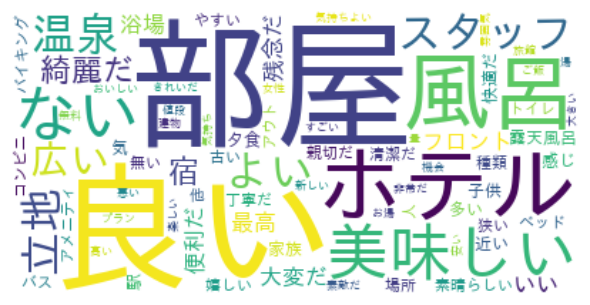

```python
# 出現回数Top 75単語でワードクラウドを作成する
words = ' '.join(word_counts_df['表層'][0:75])
plot_wordcloud(words)
```

### 1.6 「文書-抽出語」表の作成

「文書-抽出語」表を作成する (出現回数 Top 75語)

```python
# 「単語出現回数」 表から出現回数Top 75語のみ抽出する
word_counts_75_df = word_counts_df[0:75]

# 「文書-抽出語」 表も出現回数Top 75語のみに絞り込む
merged_df = pd.merge(docs_df, word_counts_75_df, how="inner", on="dict_key", suffixes=["", "_right"])
docs_75_df = merged_df[["文書ID", "単語ID", "表層", "品詞", "カテゴリー", "エリア", "dict_key"]]

# 「カテゴリー,エリア」でクロス集計する
cross_75_df = pd.crosstab(
    [
        docs_75_df['カテゴリー'],
        docs_75_df['エリア'],
        docs_75_df['文書ID']
    ],
    docs_75_df['単語ID'], margins=False
)
cross_75_df.columns = word_counts_75_df["表層"]

# DataFrame を表示する
print(cross_75_df.shape)
display(cross_75_df)
```

```
(9630, 75)
```

| カテゴリー | エリア | 表層 文書ID | 部屋 | 良い | ホテル | 風呂 | 美味しい | ない | スタッフ | 温泉 | よい | 立地 | ... | 新しい | 楽しい | 気持ち | 雰囲気 | 女性 | 高い | 建物 | すごい | 大きい | 量 |
| --- | --- | --- | --- | --- | --- | --- | --- | --- | --- | --- | --- | --- | --- | --- | --- | --- | --- | --- | --- | --- | --- | --- | --- |
| A_レジャー | 01_登別 | 1 | 0 | 0 | 0 | 2 | 1 | 0 | 1 | 0 | 0 | 0 | ... | 0 | 0 | 0 | 0 | 0 | 0 | 0 | 0 | 0 | 0 |
|  |  | 2 | 0 | 1 | 0 | 0 | 1 | 0 | 0 | 0 | 0 | 0 | ... | 0 | 0 | 0 | 0 | 0 | 0 | 0 | 0 | 0 | 0 |
|  |  | 3 | 1 | 1 | 0 | 0 | 0 | 1 | 0 | 1 | 0 | 0 | ... | 0 | 0 | 0 | 0 | 0 | 0 | 0 | 0 | 0 | 0 |
|  |  | 4 | 1 | 0 | 0 | 1 | 0 | 0 | 0 | 0 | 0 | 0 | ... | 0 | 0 | 0 | 0 | 0 | 0 | 0 | 0 | 0 | 0 |
|  |  | 5 | 0 | 0 | 0 | 0 | 1 | 0 | 0 | 0 | 0 | 1 | ... | 0 | 0 | 0 | 0 | 0 | 0 | 0 | 0 | 0 | 0 |
| ... | ... | ... | ... | ... | ... | ... | ... | ... | ... | ... | ... | ... | ... | ... | ... | ... | ... | ... | ... | ... | ... | ... | ... |
| B_ビジネス | 10_福岡 | 9996 | 0 | 1 | 0 | 0 | 0 | 1 | 0 | 0 | 0 | 0 | ... | 0 | 0 | 0 | 0 | 0 | 0 | 0 | 0 | 0 | 0 |
|  |  | 9997 | 1 | 0 | 0 | 0 | 0 | 0 | 0 | 0 | 0 | 0 | ... | 0 | 0 | 0 | 0 | 0 | 0 | 0 | 0 | 1 | 0 |
|  |  | 9998 | 0 | 0 | 0 | 0 | 1 | 0 | 0 | 0 | 1 | 0 | ... | 0 | 0 | 0 | 0 | 0 | 0 | 0 | 0 | 0 | 0 |
|  |  | 9999 | 0 | 0 | 0 | 0 | 0 | 0 | 0 | 0 | 0 | 0 | ... | 0 | 0 | 0 | 0 | 0 | 0 | 0 | 0 | 0 | 0 |
|  |  | 10000 | 0 | 2 | 1 | 0 | 0 | 0 | 1 | 0 | 0 | 0 | ... | 0 | 0 | 0 | 0 | 0 | 1 | 0 | 0 | 0 | 0 |

9630 rows × 75 columns

「文書-抽出語」 表を {0,1} に変換する

```python
# 「文書-抽出語」 表を {0,1} に変換する
cross_75_df[cross_75_df > 0] = 1

# DataFrame を表示する
print(cross_75_df.shape)
display(cross_75_df)
```

```
(9630, 75)
```

| カテゴリー | エリア | 表層 文書ID | 部屋 | 良い | ホテル | 風呂 | 美味しい | ない | スタッフ | 温泉 | よい | 立地 | ... | 新しい | 楽しい | 気持ち | 雰囲気 | 女性 | 高い | 建物 | すごい | 大きい | 量 |
| --- | --- | --- | --- | --- | --- | --- | --- | --- | --- | --- | --- | --- | --- | --- | --- | --- | --- | --- | --- | --- | --- | --- | --- |
| A_レジャー | 01_登別 | 1 | 0 | 0 | 0 | 1 | 1 | 0 | 1 | 0 | 0 | 0 | ... | 0 | 0 | 0 | 0 | 0 | 0 | 0 | 0 | 0 | 0 |
|  |  | 2 | 0 | 1 | 0 | 0 | 1 | 0 | 0 | 0 | 0 | 0 | ... | 0 | 0 | 0 | 0 | 0 | 0 | 0 | 0 | 0 | 0 |
|  |  | 3 | 1 | 1 | 0 | 0 | 0 | 1 | 0 | 1 | 0 | 0 | ... | 0 | 0 | 0 | 0 | 0 | 0 | 0 | 0 | 0 | 0 |
|  |  | 4 | 1 | 0 | 0 | 1 | 0 | 0 | 0 | 0 | 0 | 0 | ... | 0 | 0 | 0 | 0 | 0 | 0 | 0 | 0 | 0 | 0 |
|  |  | 5 | 0 | 0 | 0 | 0 | 1 | 0 | 0 | 0 | 0 | 1 | ... | 0 | 0 | 0 | 0 | 0 | 0 | 0 | 0 | 0 | 0 |
| ... | ... | ... | ... | ... | ... | ... | ... | ... | ... | ... | ... | ... | ... | ... | ... | ... | ... | ... | ... | ... | ... | ... | ... |
| B_ビジネス | 10_福岡 | 9996 | 0 | 1 | 0 | 0 | 0 | 1 | 0 | 0 | 0 | 0 | ... | 0 | 0 | 0 | 0 | 0 | 0 | 0 | 0 | 0 | 0 |
|  |  | 9997 | 1 | 0 | 0 | 0 | 0 | 0 | 0 | 0 | 0 | 0 | ... | 0 | 0 | 0 | 0 | 0 | 0 | 0 | 0 | 1 | 0 |
|  |  | 9998 | 0 | 0 | 0 | 0 | 1 | 0 | 0 | 0 | 1 | 0 | ... | 0 | 0 | 0 | 0 | 0 | 0 | 0 | 0 | 0 | 0 |
|  |  | 9999 | 0 | 0 | 0 | 0 | 0 | 0 | 0 | 0 | 0 | 0 | ... | 0 | 0 | 0 | 0 | 0 | 0 | 0 | 0 | 0 | 0 |
|  |  | 10000 | 0 | 1 | 1 | 0 | 0 | 0 | 1 | 0 | 0 | 0 | ... | 0 | 0 | 0 | 0 | 0 | 1 | 0 | 0 | 0 | 0 |

9630 rows × 75 columns

### 1.7 共起ネットワーク図

#### 1.7.1 共起度行列を作成する (抽出語-抽出語)

```python
# 必要ライブラリのインポート
from scipy.sparse import csc_matrix

# 共起行列を作成する
X = cross_75_df.values
X = csc_matrix(X)
Xc = (X.T * X)
# 対角成分のみにする
Xc = np.triu(Xc.toarray())

# DataFrame 型に整える
cooccur_75_df = pd.DataFrame(Xc, columns=cross_75_df.columns, index=cross_75_df.columns)

# DataFrame を表示する
print(cooccur_75_df.shape)
display(cooccur_75_df.head())
```

```
(75, 75)
```

| 表層 | 部屋 | 良い | ホテル | 風呂 | 美味しい | ない | スタッフ | 温泉 | よい | 立地 | ... | 新しい | 楽しい | 気持ち | 雰囲気 | 女性 | 高い | 建物 | すごい | 大きい | 量 |
| --- | --- | --- | --- | --- | --- | --- | --- | --- | --- | --- | --- | --- | --- | --- | --- | --- | --- | --- | --- | --- | --- |
| 部屋 | 4568 | 1961 | 1091 | 1273 | 1068 | 1012 | 783 | 706 | 676 | 691 | ... | 200 | 175 | 192 | 190 | 183 | 187 | 177 | 190 | 186 | 174 |
| 良い | 0 | 3701 | 892 | 1026 | 896 | 692 | 712 | 638 | 339 | 701 | ... | 140 | 121 | 201 | 175 | 142 | 136 | 140 | 133 | 132 | 168 |
| ホテル | 0 | 0 | 2041 | 391 | 354 | 506 | 411 | 235 | 267 | 356 | ... | 120 | 70 | 101 | 80 | 102 | 102 | 53 | 78 | 73 | 56 |
| 風呂 | 0 | 0 | 0 | 2143 | 598 | 503 | 376 | 359 | 333 | 317 | ... | 83 | 102 | 112 | 100 | 101 | 84 | 93 | 77 | 134 | 120 |
| 美味しい | 0 | 0 | 0 | 0 | 1962 | 379 | 432 | 429 | 229 | 215 | ... | 67 | 118 | 92 | 97 | 74 | 69 | 85 | 93 | 81 | 142 |

5 rows × 75 columns

#### 1.7.2 Jaccard 係数を求める (抽出語-抽出語)

```python
# 共起行列の中身を Jaccard 係数に入れ替える
jaccard_75_df = jaccard_coef(cooccur_75_df, cross_75_df)

# DataFrame を表示する
print(jaccard_75_df.shape)
display(jaccard_75_df.head())
```

```
(75, 75)
```

| 表層 | 部屋 | 良い | ホテル | 風呂 | 美味しい | ない | スタッフ | 温泉 | よい | 立地 | ... | 新しい | 楽しい | 気持ち | 雰囲気 | 女性 | 高い | 建物 | すごい | 大きい | 量 |
| --- | --- | --- | --- | --- | --- | --- | --- | --- | --- | --- | --- | --- | --- | --- | --- | --- | --- | --- | --- | --- | --- |
| 部屋 | 0.0 | 0.310875 | 0.197717 | 0.234093 | 0.195533 | 0.195178 | 0.150693 | 0.136822 | 0.132627 | 0.132757 | ... | 0.042635 | 0.037163 | 0.040929 | 0.040572 | 0.039170 | 0.039991 | 0.037716 | 0.040808 | 0.039820 | 0.037148 |
| 良い | 0.0 | 0.000000 | 0.183918 | 0.212951 | 0.187959 | 0.149202 | 0.161818 | 0.146297 | 0.074228 | 0.161969 | ... | 0.036045 | 0.031057 | 0.052687 | 0.045680 | 0.036921 | 0.035233 | 0.036241 | 0.034581 | 0.034215 | 0.043945 |
| ホテル | 0.0 | 0.000000 | 0.000000 | 0.103085 | 0.097013 | 0.159924 | 0.135153 | 0.075709 | 0.089627 | 0.118155 | ... | 0.053476 | 0.030608 | 0.044789 | 0.035305 | 0.045822 | 0.045658 | 0.023144 | 0.034806 | 0.032344 | 0.024615 |
| 風呂 | 0.0 | 0.000000 | 0.000000 | 0.000000 | 0.170516 | 0.153870 | 0.118313 | 0.116483 | 0.110448 | 0.100507 | ... | 0.034830 | 0.043275 | 0.047741 | 0.042589 | 0.043366 | 0.035684 | 0.039541 | 0.032850 | 0.058312 | 0.051881 |
| 美味しい | 0.0 | 0.000000 | 0.000000 | 0.000000 | 0.000000 | 0.117995 | 0.146889 | 0.151537 | 0.077944 | 0.069919 | ... | 0.030207 | 0.054630 | 0.042105 | 0.044700 | 0.034023 | 0.031536 | 0.039009 | 0.043316 | 0.037327 | 0.067299 |

5 rows × 75 columns

### 1.7.3 プロットする

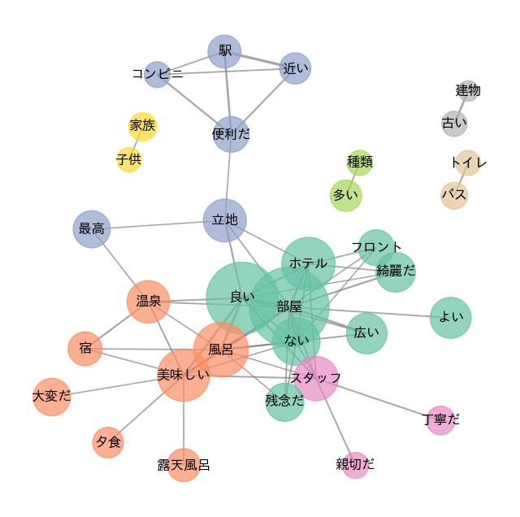

```python
# 抽出語の出現回数(ノードの大きさ)を取得する
word_counts = cross_75_df.sum(axis=0).values

# 共起行列(Jaccard係数)で共起ネットワーク図を作成する
plot_cooccur_network(jaccard_75_df, word_counts, np.sort(jaccard_75_df.values.reshape(-1))[::-1][60])
```

### 1.8 係り受けネットワーク図

#### 1.8.1 係り受け行列を作成する

```python
# チャンク(文節)から単語を取り出す
def get_words(tree, from_chunk, stopwords):

    # チャンク(文節)の開始位置を取得する
    beg = from_chunk.token_pos

    # チャンクの開始位置を取得する
    end = from_chunk.token_pos + from_chunk.token_size

    # 抽出語情報リストの初期化
    words = []

    # チャンク(文節)ごとのループ
    for i in range(beg, end):

        # チャンク中の形態素を取り出す
        token = tree.token(i)

        # 解析結果を要素ごとにバラす
        features = token.feature.split(',')

        # 品詞1 を取り出す
        pos1 = features[0]

        # 品詞2 を取り出す
        pos2 = features[1] if len(features) > 1 else ""

        # 原形 を取り出す
        base = features[6] if len(features) > 6 else None

        # 原型がストップワードに含まれない単語のみ抽出する
        if base not in stopwords:

            # 「名詞-一般」
            if (pos1 == "名詞" and pos2 == "一般"):
                base = base if base is not None else node.surface
                postag = "名詞"
                key = (base, postag)

                # 抽出語情報をリストに追加する
                words.append(key)

            # 「形容動詞」
            elif (pos1 == "名詞" and pos2 == "形容動詞語幹"):
                base = base if base is not None else node.surface
                base = f"{base}だ"
                postag = "形容動詞"
                key = (base, postag)

                # 抽出語情報をリストに追加する
                words.append(key)

            # 「形容詞」
            elif pos1 == "形容詞":
                base = base if base is not None else node.surface
                postag = "形容詞"
                key = (base, postag)

                # 抽出語情報をリストに追加する
                words.append(key)

            # 「未知語」
            elif pos1 == "未知語":
                base = base if base is not None else node.surface
                postag = "未知語"
                key = (base, postag)

                # 抽出語情報をリストに追加する
                words.append(key)

    # 抽出語情報をリストを返却する
    return words


# 必要ライブラリのインポート
import CaboCha

# cabocha の初期化
cp = CaboCha.Parser("-r ../tools/usr/local/etc/cabocharc")

# 半角->全角変換マクロを定義する
ZEN = "".join(chr(0xff01 + i) for i in range(94))
HAN = "".join(chr(0x21 + i) for i in range(94))
HAN2ZEN = str.maketrans(HAN, ZEN)

# ストップワードを定義する
# stopwords = ['する', 'ある', 'ない', 'いう', 'もの', 'こと', 'よう', 'なる', 'ほう']
stopwords = ['*']  # 原形に 「'*'」 が出力された場合に除去するため

# 係り受けペア辞書の初期化
pair_counts = defaultdict(lambda: 0)
pairs = []

# データ1行ごとのループ
for index, row in all_df.iterrows():

    # 半角->全角変換した後で, cabocha で解析する
    tree = cp.parse(row["コメント"].translate(HAN2ZEN))

    # 解析結果から空でないチャンク(文節)のリストを集める
    chunks = {}
    key = 0
    for i in range(tree.size()):
        tok = tree.token(i)
        if tok.chunk:
            chunks[key] = tok.chunk
            key += 1

    # 係り元と係り先の単語情報(原形と品詞)を集める
    for from_chunk in chunks.values():
        # 係り先がなければスキップ
        if from_chunk.link < 0:
            continue

        # 係り先のチャンク(文節)を取得する
        to_chunk = chunks[from_chunk.link]

        # 係り元の単語情報(原形と品詞)を取得する
        from_words = get_words(tree, from_chunk, stopwords)

        # 係り先の単語情報(原形と品詞)を取得する
        to_words = get_words(tree, to_chunk, stopwords)

    # 係り受けペアと頻度を収集する
    for f in from_words:
        for t in to_words:
            key = (f[0], t[0])
            pair_counts[key] += 1


# 係り受け行列を初期化する (共起行列と同じ形)
Xd = np.zeros(cooccur_75_df.shape)

# 係り受けペアを係り受け列に変換する
for (f,t), v in pair_counts.items():
    columns = list(cooccur_75_df.columns)
    if f in columns and t in columns:
        i = columns.index(f)
        j = columns.index(t)
        Xd[i,j] = v

# DataFrme 型に整える
dep_75_df = pd.DataFrame(Xd, columns=cooccur_75_df.columns, index=cooccur_75_df.columns)
print(dep_75_df.shape)
display(dep_75_df.head())
```

```
(75, 75)
```

| 表層 | 部屋 | 良い | ホテル | 風呂 | 美味しい | ない | スタッフ | 温泉 | よい | 立地 | ... | 新しい | 楽しい | 気持ち | 雰囲気 | 女性 | 高い | 建物 | すごい | 大きい | 量 |
| --- | --- | --- | --- | --- | --- | --- | --- | --- | --- | --- | --- | --- | --- | --- | --- | --- | --- | --- | --- | --- | --- |
| 部屋 | 0.0 | 6.0 | 0.0 | 0.0 | 0.0 | 0.0 | 0.0 | 0.0 | 4.0 | 0.0 | ... | 0.0 | 0.0 | 0.0 | 0.0 | 0.0 | 0.0 | 0.0 | 0.0 | 0.0 | 0.0 |
| 良い | 1.0 | 3.0 | 21.0 | 0.0 | 4.0 | 1.0 | 0.0 | 0.0 | 1.0 | 0.0 | ... | 0.0 | 1.0 | 1.0 | 0.0 | 0.0 | 0.0 | 0.0 | 0.0 | 0.0 | 0.0 |
| ホテル | 1.0 | 6.0 | 0.0 | 0.0 | 0.0 | 1.0 | 0.0 | 0.0 | 1.0 | 1.0 | ... | 0.0 | 0.0 | 0.0 | 0.0 | 0.0 | 0.0 | 0.0 | 0.0 | 0.0 | 0.0 |
| 風呂 | 0.0 | 14.0 | 0.0 | 0.0 | 0.0 | 0.0 | 0.0 | 0.0 | 4.0 | 0.0 | ... | 0.0 | 0.0 | 0.0 | 0.0 | 0.0 | 0.0 | 0.0 | 0.0 | 0.0 | 0.0 |
| 美味しい | 0.0 | 3.0 | 0.0 | 0.0 | 0.0 | 0.0 | 0.0 | 0.0 | 0.0 | 0.0 | ... | 0.0 | 1.0 | 0.0 | 0.0 | 0.0 | 0.0 | 0.0 | 0.0 | 0.0 | 0.0 |

5 rows × 75 columns

#### 1.8.2 条件付き確率を求める

```python
# 係り受け行列の中身(numpy行列)を取り出す
Xc = dep_75_df.values

# 係り受け行列(条件付き確率)を初期化する (元の係り受け行列と同じ形)
Xd = np.zeros(Xc.shape)

# 係り元単語の出現頻度を取得する
word_counts = cooccur_75_df.sum(axis=0).values

# 係り受けペアごとのループ
for (f,t), v in pair_counts.items():
    columns = list(dep_75_df.columns)

    # 係り元と係り先の両方が列に含まれる
    if f in columns and t in columns:
        i = columns.index(f)
        j = columns.index(t)

        # 条件付き確率(係り受け頻度/係り先出現回数)を求める
        Xd[i,j] = v / word_counts[i]

# DataFrame 型に整える
dep_75_df = pd.DataFrame(Xd, columns=dep_75_df.columns, index=dep_75_df.columns)

# DataFrame を表示する
print(dep_75_df.shape)
display(dep_75_df.head())
```

```
(75, 75)
```

| 表層 | 部屋 | 良い | ホテル | 風呂 | 美味しい | ない | スタッフ | 温泉 | よい | 立地 | ... | 新しい | 楽しい | 気持ち | 雰囲気 | 女性 | 高い | 建物 | すごい | 大きい | 量 |
| --- | --- | --- | --- | --- | --- | --- | --- | --- | --- | --- | --- | --- | --- | --- | --- | --- | --- | --- | --- | --- | --- |
| 部屋 | 0.000000 | 0.001313 | 0.000000 | 0.0 | 0.000000 | 0.000000 | 0.0 | 0.0 | 0.000876 | 0.000000 | ... | 0.0 | 0.000000 | 0.000000 | 0.0 | 0.0 | 0.0 | 0.0 | 0.0 | 0.0 | 0.0 |
| 良い | 0.000177 | 0.000530 | 0.003709 | 0.0 | 0.000706 | 0.000177 | 0.0 | 0.0 | 0.000177 | 0.000000 | ... | 0.0 | 0.000177 | 0.000177 | 0.0 | 0.0 | 0.0 | 0.0 | 0.0 | 0.0 | 0.0 |
| ホテル | 0.000249 | 0.001491 | 0.000000 | 0.0 | 0.000000 | 0.000249 | 0.0 | 0.0 | 0.000249 | 0.000249 | ... | 0.0 | 0.000000 | 0.000000 | 0.0 | 0.0 | 0.0 | 0.0 | 0.0 | 0.0 | 0.0 |
| 風呂 | 0.000000 | 0.002897 | 0.000000 | 0.0 | 0.000000 | 0.000000 | 0.0 | 0.0 | 0.000828 | 0.000000 | ... | 0.0 | 0.000000 | 0.000000 | 0.0 | 0.0 | 0.0 | 0.0 | 0.0 | 0.0 | 0.0 |
| 美味しい | 0.000000 | 0.000615 | 0.000000 | 0.0 | 0.000000 | 0.000000 | 0.0 | 0.0 | 0.000000 | 0.000000 | ... | 0.0 | 0.000205 | 0.000000 | 0.0 | 0.0 | 0.0 | 0.0 | 0.0 | 0.0 | 0.0 |

5 rows × 75 columns

#### 1.8.3 プロットする

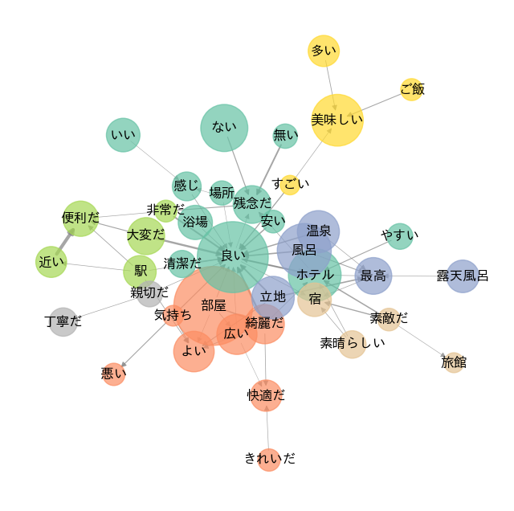

```python
# 抽出語の出現回数(ノードの大きさ)を取得する
word_counts = cross_75_df.sum(axis=0).values

# 係り受け(条件付き確率)で共起ネットワーク図を作成する
plot_dependency_network(dep_75_df, word_counts, np.sort(dep_75_df.values.reshape(-1))[::-1][60])
```

### 1.9 対応分析

「文書-抽出語」 表を確認する

```python
# DataFrame を表示する
print(cross_75_df.shape)
display(cross_75_df.head())
```

```
(9630, 75)
```

| カテゴリー | エリア | 表層 文書ID | 部屋 | 良い | ホテル | 風呂 | 美味しい | ない | スタッフ | 温泉 | よい | 立地 | ... | 新しい | 楽しい | 気持ち | 雰囲気 | 女性 | 高い | 建物 | すごい | 大きい | 量 |
| --- | --- | --- | --- | --- | --- | --- | --- | --- | --- | --- | --- | --- | --- | --- | --- | --- | --- | --- | --- | --- | --- | --- | --- |
| A_レジャー | 01_登別 | 1 | 0 | 0 | 0 | 1 | 1 | 0 | 1 | 0 | 0 | 0 | ... | 0 | 0 | 0 | 0 | 0 | 0 | 0 | 0 | 0 | 0 |
|  |  | 2 | 0 | 1 | 0 | 0 | 1 | 0 | 0 | 0 | 0 | 0 | ... | 0 | 0 | 0 | 0 | 0 | 0 | 0 | 0 | 0 | 0 |
|  |  | 3 | 1 | 1 | 0 | 0 | 0 | 1 | 0 | 1 | 0 | 0 | ... | 0 | 0 | 0 | 0 | 0 | 0 | 0 | 0 | 0 | 0 |
|  |  | 4 | 1 | 0 | 0 | 1 | 0 | 0 | 0 | 0 | 0 | 0 | ... | 0 | 0 | 0 | 0 | 0 | 0 | 0 | 0 | 0 | 0 |
|  |  | 5 | 0 | 0 | 0 | 0 | 1 | 0 | 0 | 0 | 0 | 1 | ... | 0 | 0 | 0 | 0 | 0 | 0 | 0 | 0 | 0 | 0 |

5 rows × 75 columns

#### 1.9.1 「外部変数-抽出語」 クロス集計表を作成する

```python
# 「カテゴリー」のクロス集計と「エリア」のクロス集計を連結する
aggregate_75_df = pd.concat(
    [
        cross_75_df.groupby(level='カテゴリー').sum(),
        cross_75_df.groupby(level='エリア').sum()
    ]
)

# DataFrame を表示する
print(aggregate_75_df.shape)
display(aggregate_75_df)
```

```
(12, 75)
```

| 表層 | 部屋 | 良い | ホテル | 風呂 | 美味しい | ない | スタッフ | 温泉 | よい | 立地 | ... | 新しい | 楽しい | 気持ち | 雰囲気 | 女性 | 高い | 建物 | すごい | 大きい | 量 |
| --- | --- | --- | --- | --- | --- | --- | --- | --- | --- | --- | --- | --- | --- | --- | --- | --- | --- | --- | --- | --- | --- |
| A_レジャー | 2398 | 2046 | 757 | 1535 | 1430 | 880 | 888 | 1188 | 631 | 518 | ... | 136 | 251 | 202 | 218 | 127 | 161 | 215 | 161 | 166 | 260 |
| B_ビジネス | 2170 | 1655 | 1284 | 608 | 532 | 749 | 523 | 110 | 574 | 810 | ... | 187 | 65 | 113 | 87 | 160 | 134 | 87 | 117 | 123 | 30 |
| 01_登別 | 447 | 409 | 194 | 323 | 255 | 187 | 148 | 222 | 114 | 38 | ... | 25 | 42 | 32 | 26 | 22 | 33 | 54 | 38 | 42 | 24 |
| 02_草津 | 488 | 434 | 181 | 352 | 274 | 180 | 154 | 275 | 117 | 155 | ... | 23 | 53 | 43 | 33 | 25 | 30 | 53 | 28 | 34 | 57 |
| 03_箱根 | 548 | 436 | 134 | 326 | 355 | 202 | 212 | 212 | 133 | 57 | ... | 30 | 62 | 43 | 55 | 36 | 35 | 54 | 31 | 31 | 73 |
| 04_道後 | 416 | 349 | 191 | 181 | 174 | 130 | 135 | 225 | 137 | 176 | ... | 37 | 32 | 31 | 29 | 13 | 28 | 32 | 25 | 28 | 29 |
| 05_湯布院 | 499 | 418 | 57 | 353 | 372 | 181 | 239 | 254 | 130 | 92 | ... | 21 | 62 | 53 | 75 | 31 | 35 | 22 | 39 | 31 | 77 |
| 06_札幌 | 452 | 346 | 255 | 121 | 129 | 151 | 114 | 38 | 103 | 166 | ... | 34 | 16 | 15 | 24 | 28 | 30 | 12 | 18 | 34 | 6 |
| 07_名古屋 | 434 | 310 | 241 | 116 | 97 | 144 | 102 | 18 | 133 | 141 | ... | 40 | 13 | 22 | 13 | 42 | 28 | 14 | 17 | 25 | 3 |
| 08_東京 | 441 | 338 | 240 | 106 | 99 | 131 | 99 | 12 | 104 | 166 | ... | 36 | 14 | 26 | 9 | 30 | 18 | 19 | 25 | 19 | 10 |
| 09_大阪 | 431 | 317 | 297 | 135 | 88 | 162 | 93 | 20 | 121 | 161 | ... | 32 | 10 | 27 | 24 | 37 | 26 | 20 | 31 | 19 | 3 |
| 10_福岡 | 412 | 344 | 251 | 130 | 119 | 161 | 115 | 22 | 113 | 176 | ... | 45 | 12 | 23 | 17 | 23 | 32 | 22 | 26 | 26 | 8 |

12 rows × 75 columns

#### 1.9.2 対応分析プロットを作成する

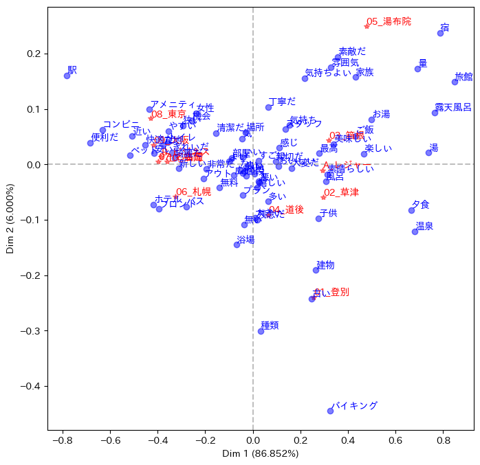

```python
# 必要ライブラリのインポート
import mca

# ライブラリ mca による対応分析
ncols = aggregate_75_df.shape[1]
mca_ben = mca.MCA(aggregate_75_df, ncols=ncols, benzecri=False)

# 行方向および列方向の値を取り出す
row_coord = mca_ben.fs_r(N=2)
col_coord = mca_ben.fs_c(N=2)

# 固有値を求める
eigenvalues = mca_ben.L
total = np.sum(eigenvalues)
# 寄与率を求める
explained_inertia = 100 * eigenvalues / total

# 行方向および列方向のラベルを取得する
row_labels = aggregate_75_df.index
col_labels = aggregate_75_df.columns

# プロットする
plot_coresp(row_coord, col_coord, row_labels, col_labels, explained_inertia)
```

### 1.10 トピックモデル

「文書-抽出語」 表を確認する

```python
# DataFrame を表示する
print(cross_75_df.shape)
display(cross_75_df.head())
```

```
(9630, 75)
```

| カテゴリー | エリア | 表層 文書ID | 部屋 | 良い | ホテル | 風呂 | 美味しい | ない | スタッフ | 温泉 | よい | 立地 | ... | 新しい | 楽しい | 気持ち | 雰囲気 | 女性 | 高い | 建物 | すごい | 大きい | 量 |
| --- | --- | --- | --- | --- | --- | --- | --- | --- | --- | --- | --- | --- | --- | --- | --- | --- | --- | --- | --- | --- | --- | --- | --- |
| A_レジャー | 01_登別 | 1 | 0 | 0 | 0 | 1 | 1 | 0 | 1 | 0 | 0 | 0 | ... | 0 | 0 | 0 | 0 | 0 | 0 | 0 | 0 | 0 | 0 |
|  |  | 2 | 0 | 1 | 0 | 0 | 1 | 0 | 0 | 0 | 0 | 0 | ... | 0 | 0 | 0 | 0 | 0 | 0 | 0 | 0 | 0 | 0 |
|  |  | 3 | 1 | 1 | 0 | 0 | 0 | 1 | 0 | 1 | 0 | 0 | ... | 0 | 0 | 0 | 0 | 0 | 0 | 0 | 0 | 0 | 0 |
|  |  | 4 | 1 | 0 | 0 | 1 | 0 | 0 | 0 | 0 | 0 | 0 | ... | 0 | 0 | 0 | 0 | 0 | 0 | 0 | 0 | 0 | 0 |
|  |  | 5 | 0 | 0 | 0 | 0 | 1 | 0 | 0 | 0 | 0 | 1 | ... | 0 | 0 | 0 | 0 | 0 | 0 | 0 | 0 | 0 | 0 |

5 rows × 75 columns

#### 1.10.1 トピックを抽出する (LDA)

```python
# 必要ライブラリのインポート
from sklearn.decomposition import LatentDirichletAllocation as LDA

# ライブラリ LDA によるトピック抽出
lda = LDA(max_iter=25, learning_method='batch', random_state=0, n_jobs=-1, n_components=6)
lda.fit(cross_75_df.values)

# トピックごとに出現確率Top 20語を表示する
n_top_words = 20
feature_names = cross_75_df.columns
for topic_idx, topic in enumerate(lda.components_):
    print(f"Topic # {topic_idx+1}:", end=" ")
    for i in topic.argsort()[:-n_top_words-1:-1]:
        print(feature_names[i], end=" ")
    print()
```

```
Topic # 1: 部屋 ない 残念だ 良い 浴場 ホテル フロント 風呂 バス 無い ベッド 狭い トイレ 広い 他 新しい いい 悪い 気 よい
Topic # 2: スタッフ よい 多い 良い 部屋 ホテル 美味しい 種類 ない 嬉しい プラン 親切だ フロント バイキング 残念だ アウト すごい 子供 人 感じ
Topic # 3: 立地 良い 綺麗だ ホテル 部屋 最高 非常だ 快適だ アメニティ 清潔だ 値段 いい 無料 女性 便利だ 風呂 ない 大変だ 建物 美味しい
Topic # 4: 温泉 美味しい 良い 宿 露天風呂 部屋 風呂 素晴らしい 最高 夕食 スタッフ 雰囲気 旅館 湯 大変だ ない お湯 量 浴場 いい
Topic # 5: 部屋 広い 風呂 大変だ 良い 快適だ 美味しい 丁寧だ 綺麗だ 機会 清潔だ スタッフ 気持ちよい 家族 よい 楽しい おいしい 親切だ 子供 大きい
Topic # 6: 便利だ 駅 近い コンビニ やすい 部屋 良い きれいだ 場所 ホテル 安い バス いい 快適だ 機会 フロント 気 アウト 多い 無料
```

#### 1.10.2 結果をワードクラウドで描画する

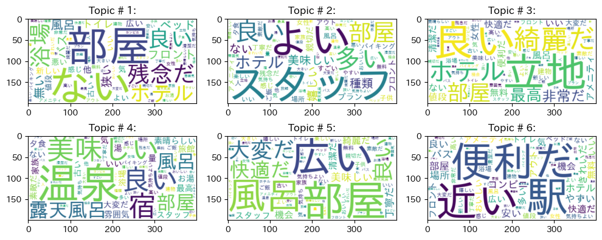

```python
# トピックごとに出現確率Top 75語をプロットする
n_top_words = 75
plot_topic_model(lda, feature_names, n_top_words)
```

### 1.11 外部変数の利用

#### 1.11.1 「文書-抽出語」表の作成

「文書-抽出語」表を作成する (出現回数 Top 150語)

```python
# 「単語出現回数」 表から出現回数Top 150語のみ抽出する
word_counts_150_df = word_counts_df[0:150]

# 「文書-抽出語」 表も出現回数Top 150語のみに絞り込む
merged_df = pd.merge(docs_df, word_counts_150_df, how="inner", on="dict_key", suffixes=["", "_right"])
docs_150_df = merged_df[["文書ID", "単語ID", "表層", "品詞", "カテゴリー", "エリア", "dict_key"]]

# 「カテゴリー,エリア」でクロス集計する
cross_150_df = pd.crosstab(
    [
        docs_150_df['カテゴリー'],
        docs_150_df['エリア'],
        docs_150_df['文書ID']
    ],
    docs_150_df['単語ID'], margins=False
)
cross_150_df.columns = word_counts_150_df["表層"]
```

「文書-抽出語」表を {0,1} に変換する

```python
# 「文書-抽出語」 表を {0,1} に変換する
cross_150_df[cross_150_df > 0] = 1

# DataFrame を表示する
print(cross_150_df.shape)
display(cross_150_df)
```

```
(9762, 150)
```

| カテゴリー | エリア | 表層 文書ID | 部屋 | 良い | ホテル | 風呂 | 美味しい | ない | スタッフ | 温泉 | よい | 立地 | ... | 事前 | テレビ | にくい | 遠い | 寒い | 布団 | 男性 | 隣 | 口コミ | スペース |
| --- | --- | --- | --- | --- | --- | --- | --- | --- | --- | --- | --- | --- | --- | --- | --- | --- | --- | --- | --- | --- | --- | --- | --- |
| A_レジャー | 01_登別 | 1 | 0 | 0 | 0 | 1 | 1 | 0 | 1 | 0 | 0 | 0 | ... | 0 | 0 | 0 | 0 | 0 | 0 | 0 | 0 | 0 | 0 |
|  |  | 2 | 0 | 1 | 0 | 0 | 1 | 0 | 0 | 0 | 0 | 0 | ... | 0 | 0 | 0 | 0 | 0 | 0 | 0 | 0 | 0 | 0 |
|  |  | 3 | 1 | 1 | 0 | 0 | 0 | 1 | 0 | 1 | 0 | 0 | ... | 0 | 0 | 0 | 0 | 0 | 0 | 0 | 0 | 0 | 0 |
|  |  | 4 | 1 | 0 | 0 | 1 | 0 | 0 | 0 | 0 | 0 | 0 | ... | 0 | 0 | 0 | 0 | 0 | 0 | 0 | 0 | 0 | 0 |
|  |  | 5 | 0 | 0 | 0 | 0 | 1 | 0 | 0 | 0 | 0 | 1 | ... | 0 | 0 | 0 | 0 | 0 | 0 | 0 | 0 | 0 | 0 |
| ... | ... | ... | ... | ... | ... | ... | ... | ... | ... | ... | ... | ... | ... | ... | ... | ... | ... | ... | ... | ... | ... | ... | ... |
| B_ビジネス | 10_福岡 | 9996 | 0 | 1 | 0 | 0 | 0 | 1 | 0 | 0 | 0 | 0 | ... | 0 | 0 | 0 | 0 | 0 | 0 | 0 | 0 | 0 | 0 |
|  |  | 9997 | 1 | 0 | 0 | 0 | 0 | 0 | 0 | 0 | 0 | 0 | ... | 0 | 1 | 0 | 0 | 0 | 0 | 0 | 0 | 0 | 0 |
|  |  | 9998 | 0 | 0 | 0 | 0 | 1 | 0 | 0 | 0 | 1 | 0 | ... | 0 | 0 | 0 | 0 | 0 | 0 | 0 | 0 | 0 | 0 |
|  |  | 9999 | 0 | 0 | 0 | 0 | 0 | 0 | 0 | 0 | 0 | 0 | ... | 0 | 0 | 0 | 0 | 0 | 0 | 0 | 0 | 0 | 0 |
|  |  | 10000 | 0 | 1 | 1 | 0 | 0 | 0 | 1 | 0 | 0 | 0 | ... | 1 | 0 | 0 | 0 | 0 | 0 | 0 | 0 | 0 | 0 |

9762 rows × 150 columns

#### 1.11.2 共起行列を作成する (外部変数-抽出語)

```python
# 「カテゴリー」のクロス集計と「エリア」のクロス集計を連結する
aggregate_df = pd.concat(
    [
        cross_150_df.groupby(level='カテゴリー').sum(),
        cross_150_df.groupby(level='エリア').sum()
    ]
)

# DataFrame を表示する
print(aggregate_df.shape)
display(aggregate_df)
```

```
(12, 150)
```

| 表層 | 部屋 | 良い | ホテル | 風呂 | 美味しい | ない | スタッフ | 温泉 | よい | 立地 | ... | 事前 | テレビ | にくい | 遠い | 寒い | 布団 | 男性 | 隣 | 口コミ | スペース |
| --- | --- | --- | --- | --- | --- | --- | --- | --- | --- | --- | --- | --- | --- | --- | --- | --- | --- | --- | --- | --- | --- |
| A_レジャー | 2398 | 2046 | 757 | 1535 | 1430 | 880 | 888 | 1188 | 631 | 518 | ... | 92 | 53 | 85 | 87 | 102 | 106 | 84 | 61 | 97 | 56 |
| B_ビジネス | 2170 | 1655 | 1284 | 608 | 532 | 749 | 523 | 110 | 574 | 810 | ... | 62 | 99 | 74 | 78 | 35 | 31 | 57 | 91 | 38 | 88 |
| 01_登別 | 447 | 409 | 194 | 323 | 255 | 187 | 148 | 222 | 114 | 38 | ... | 11 | 9 | 10 | 20 | 17 | 27 | 9 | 17 | 6 | 6 |
| 02_草津 | 488 | 434 | 181 | 352 | 274 | 180 | 154 | 275 | 117 | 155 | ... | 17 | 9 | 15 | 25 | 17 | 20 | 21 | 12 | 28 | 5 |
| 03_箱根 | 548 | 436 | 134 | 326 | 355 | 202 | 212 | 212 | 133 | 57 | ... | 26 | 11 | 15 | 15 | 30 | 31 | 24 | 7 | 25 | 20 |
| 04_道後 | 416 | 349 | 191 | 181 | 174 | 130 | 135 | 225 | 137 | 176 | ... | 13 | 10 | 20 | 9 | 8 | 8 | 16 | 12 | 10 | 12 |
| 05_湯布院 | 499 | 418 | 57 | 353 | 372 | 181 | 239 | 254 | 130 | 92 | ... | 25 | 14 | 25 | 18 | 30 | 20 | 14 | 13 | 28 | 13 |
| 06_札幌 | 452 | 346 | 255 | 121 | 129 | 151 | 114 | 38 | 103 | 166 | ... | 13 | 21 | 17 | 11 | 10 | 6 | 12 | 11 | 8 | 17 |
| 07_名古屋 | 434 | 310 | 241 | 116 | 97 | 144 | 102 | 18 | 133 | 141 | ... | 11 | 17 | 11 | 22 | 10 | 2 | 10 | 23 | 9 | 14 |
| 08_東京 | 441 | 338 | 240 | 106 | 99 | 131 | 99 | 12 | 104 | 166 | ... | 8 | 16 | 14 | 13 | 5 | 9 | 15 | 17 | 5 | 24 |
| 09_大阪 | 431 | 317 | 297 | 135 | 88 | 162 | 93 | 20 | 121 | 161 | ... | 12 | 25 | 15 | 16 | 4 | 6 | 12 | 18 | 7 | 12 |
| 10_福岡 | 412 | 344 | 251 | 130 | 119 | 161 | 115 | 22 | 113 | 176 | ... | 18 | 20 | 17 | 16 | 6 | 8 | 8 | 22 | 9 | 21 |

12 rows × 150 columns

#### 1.11.3 Jaccard 係数を求める (外部変数-抽出語)

```python
# 抽出語の出現回数を取得する
word_counts = cross_150_df.sum(axis=0).values

# 属性(外部変数)出現数を取得する
attr_counts = np.hstack(
    [
        all_df.value_counts('カテゴリー').values,
        all_df.value_counts('エリア').values
    ]
)

# 共起行列の中身を Jaccard 係数に入れ替える
jaccard_attrs_df = jaccard_attrs_coef(aggregate_df, attr_counts, word_counts, total=10000, conditional=False)

# DataFrame を表示する
print(jaccard_attrs_df.shape)
display(jaccard_attrs_df)
```

```
(12, 150)
```

| 表層 | 部屋 | 良い | ホテル | 風呂 | 美味しい | ない | スタッフ | 温泉 | よい | 立地 | ... | 事前 | テレビ | にくい | 遠い | 寒い | 布団 | 男性 | 隣 | 口コミ | スペース |
| --- | --- | --- | --- | --- | --- | --- | --- | --- | --- | --- | --- | --- | --- | --- | --- | --- | --- | --- | --- | --- | --- |
| A_レジャー | 0.334449 | 0.307438 | 0.000000 | 0.273716 | 0.258496 | 0.153070 | 0.160782 | 0.232485 | 0.113204 | 0.000000 | ... | 0.018175 | 0.000000 | 0.016752 | 0.017133 | 0.020258 | 0.021069 | 0.016611 | 0.000000 | 0.019254 | 0.000000 |
| B_ビジネス | 0.000000 | 0.000000 | 0.223033 | 0.000000 | 0.000000 | 0.000000 | 0.000000 | 0.000000 | 0.000000 | 0.146792 | ... | 0.000000 | 0.019592 | 0.000000 | 0.000000 | 0.000000 | 0.000000 | 0.000000 | 0.017981 | 0.000000 | 0.017405 |
| 01_登別 | 0.000000 | 0.095294 | 0.000000 | 0.114539 | 0.094200 | 0.076577 | 0.065400 | 0.106936 | 0.000000 | 0.000000 | ... | 0.000000 | 0.000000 | 0.000000 | 0.017467 | 0.015179 | 0.024324 | 0.000000 | 0.014978 | 0.000000 | 0.000000 |
| 02_草津 | 0.096063 | 0.101711 | 0.000000 | 0.126120 | 0.101935 | 0.073499 | 0.068232 | 0.135937 | 0.000000 | 0.071330 | ... | 0.014952 | 0.000000 | 0.000000 | 0.021930 | 0.015179 | 0.017905 | 0.018750 | 0.000000 | 0.025294 | 0.000000 |
| 03_箱根 | 0.109163 | 0.102227 | 0.000000 | 0.115726 | 0.136172 | 0.083230 | 0.096407 | 0.101630 | 0.064189 | 0.000000 | ... | 0.023050 | 0.000000 | 0.000000 | 0.000000 | 0.027100 | 0.028029 | 0.021486 | 0.000000 | 0.022523 | 0.017794 |
| 04_道後 | 0.000000 | 0.000000 | 0.000000 | 0.000000 | 0.000000 | 0.000000 | 0.000000 | 0.108538 | 0.066248 | 0.081784 | ... | 0.000000 | 0.000000 | 0.017559 | 0.000000 | 0.000000 | 0.000000 | 0.014222 | 0.000000 | 0.000000 | 0.000000 |
| 05_湯布院 | 0.098442 | 0.097595 | 0.000000 | 0.126523 | 0.143629 | 0.073938 | 0.110037 | 0.124266 | 0.062651 | 0.000000 | ... | 0.022143 | 0.000000 | 0.022046 | 0.015693 | 0.027100 | 0.017905 | 0.000000 | 0.000000 | 0.025294 | 0.000000 |
| 06_札幌 | 0.000000 | 0.000000 | 0.091529 | 0.000000 | 0.000000 | 0.000000 | 0.000000 | 0.000000 | 0.000000 | 0.076781 | ... | 0.000000 | 0.018568 | 0.014886 | 0.000000 | 0.000000 | 0.000000 | 0.000000 | 0.000000 | 0.000000 | 0.015084 |
| 07_名古屋 | 0.000000 | 0.000000 | 0.086071 | 0.000000 | 0.000000 | 0.000000 | 0.000000 | 0.000000 | 0.064189 | 0.064472 | ... | 0.000000 | 0.014978 | 0.000000 | 0.019248 | 0.000000 | 0.000000 | 0.000000 | 0.020372 | 0.000000 | 0.000000 |
| 08_東京 | 0.000000 | 0.000000 | 0.085684 | 0.000000 | 0.000000 | 0.000000 | 0.000000 | 0.000000 | 0.000000 | 0.076781 | ... | 0.000000 | 0.014085 | 0.000000 | 0.000000 | 0.000000 | 0.000000 | 0.013321 | 0.014978 | 0.000000 | 0.021429 |
| 09_大阪 | 0.000000 | 0.000000 | 0.108236 | 0.000000 | 0.000000 | 0.000000 | 0.000000 | 0.000000 | 0.058061 | 0.074296 | ... | 0.000000 | 0.022183 | 0.000000 | 0.000000 | 0.000000 | 0.000000 | 0.000000 | 0.015873 | 0.000000 | 0.000000 |
| 10_福岡 | 0.000000 | 0.000000 | 0.089964 | 0.000000 | 0.000000 | 0.000000 | 0.000000 | 0.000000 | 0.000000 | 0.081784 | ... | 0.015845 | 0.017668 | 0.014886 | 0.000000 | 0.000000 | 0.000000 | 0.000000 | 0.019469 | 0.000000 | 0.018700 |

12 rows × 150 columns

#### 1.11.4 特徴語ランキング

```python
# 「カテゴリ」や「エリア」ごとに Jaccard 係数のTop 10語を抽出する
df_list = []
for index, row in jaccard_attrs_df.iterrows():
    df_list.append(row.iloc[np.argsort(row.values)[::-1][:10]].reset_index())

# 「カテゴリ」や「エリア」ごとの Jaccard 係数のTop 10 を横方向に連結した DetaFrame を作成する
ranking_df = pd.DataFrame(pd.concat(df_list, axis=1))
ranking_df.columns = np.array([c for pair in [[x,f"jaccard"] for x in jaccard_attrs_df.index] for c in pair], dtype='object')

# DataFrame を表示する
display(ranking_df)
```

|  | A_レジャー | jaccard | B_ビジネス | jaccard | 01_登別 | jaccard | 02_草津 | jaccard | 03_箱根 | jaccard | ... | 06_札幌 | jaccard | 07_名古屋 | jaccard | 08_東京 | jaccard | 09_大阪 | jaccard | 10_福岡 | jaccard |
| --- | --- | --- | --- | --- | --- | --- | --- | --- | --- | --- | --- | --- | --- | --- | --- | --- | --- | --- | --- | --- | --- |
| 0 | 部屋 | 0.334449 | ホテル | 0.223033 | 風呂 | 0.114539 | 温泉 | 0.135937 | 美味しい | 0.136172 | ... | ホテル | 0.091529 | ホテル | 0.086071 | 駅 | 0.102041 | ホテル | 0.108236 | ホテル | 0.089964 |
| 1 | 良い | 0.307438 | 立地 | 0.146792 | 温泉 | 0.106936 | 風呂 | 0.126120 | 露天風呂 | 0.133758 | ... | 立地 | 0.076781 | 便利だ | 0.071669 | ホテル | 0.085684 | 駅 | 0.095941 | 便利だ | 0.086882 |
| 2 | 風呂 | 0.273716 | 便利だ | 0.133602 | 良い | 0.095294 | 宿 | 0.119559 | 風呂 | 0.115726 | ... | 便利だ | 0.076490 | 駅 | 0.070913 | 便利だ | 0.077703 | 便利だ | 0.080135 | 立地 | 0.081784 |
| 3 | 美味しい | 0.258496 | 駅 | 0.124465 | 美味しい | 0.094200 | 美味しい | 0.101935 | 部屋 | 0.109163 | ... | 綺麗だ | 0.071357 | 綺麗だ | 0.069208 | 立地 | 0.076781 | 立地 | 0.074296 | 駅 | 0.063881 |
| 4 | 温泉 | 0.232485 | 綺麗だ | 0.123283 | バイキング | 0.089563 | 良い | 0.101711 | 良い | 0.102227 | ... | 浴場 | 0.069540 | フロント | 0.065673 | 近い | 0.070529 | 綺麗だ | 0.072435 | フロント | 0.062741 |
| 5 | スタッフ | 0.160782 | フロント | 0.106943 | 残念だ | 0.078018 | 部屋 | 0.096063 | 温泉 | 0.101630 | ... | フロント | 0.064498 | 立地 | 0.064472 | 綺麗だ | 0.063872 | フロント | 0.067441 | 綺麗だ | 0.060169 |
| 6 | ない | 0.153070 | 近い | 0.091118 | ない | 0.076577 | 最高 | 0.090361 | 宿 | 0.096697 | ... | 広い | 0.062713 | よい | 0.064189 | 快適だ | 0.063002 | 快適だ | 0.064317 | トイレ | 0.052975 |
| 7 | 宿 | 0.152066 | 快適だ | 0.089507 | 夕食 | 0.075641 | 夕食 | 0.085382 | スタッフ | 0.096407 | ... | 快適だ | 0.055828 | 近い | 0.058531 | コンビニ | 0.058697 | 広い | 0.064265 | コンビニ | 0.052669 |
| 8 | 露天風呂 | 0.144101 | アメニティ | 0.072060 | 種類 | 0.075444 | ない | 0.073499 | 夕食 | 0.094586 | ... | 駅 | 0.055687 | アメニティ | 0.056187 | フロント | 0.055191 | 近い | 0.063164 | いい | 0.051754 |
| 9 | 最高 | 0.131658 | コンビニ | 0.069282 | 露天風呂 | 0.073583 | 大変だ | 0.072688 | ない | 0.083230 | ... | ベッド | 0.054865 | 快適だ | 0.055181 | アメニティ | 0.051965 | よい | 0.058061 | 近い | 0.050680 |

10 rows × 24 columns

#### 1.11.5 ワードクラウド (カテゴリーごと)

```
A_レジャー
```

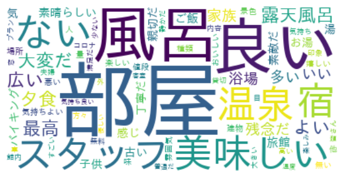

```
B_ビジネス
```

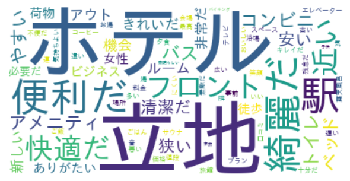

```python
for name, group in cross_150_df.groupby(level='カテゴリー'):
    print(name)

    # 「カテゴリー」ごとに Jaccard 係数でソートする
    sorted_columns = np.argsort(jaccard_attrs_df.loc[name].values)[::-1][:75]

    # Jaccard 係数Top 75語をソートして抽出する
    group_cross_df = group.iloc[:,sorted_columns]

    # プロットする
    plot_wordcloud(" ".join(group_cross_df.columns))
```

#### 1.11.6 共起ネットワーク図 (カテゴリーごと)

```
A_レジャー
```

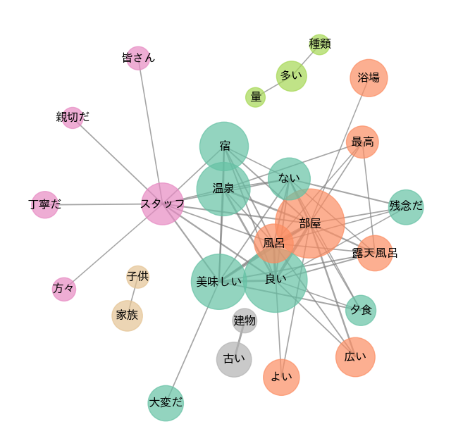

```
B_ビジネス
```

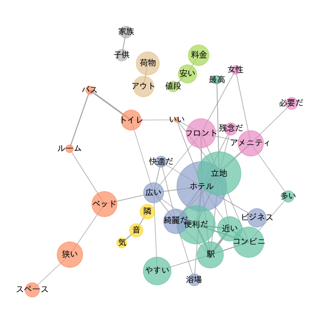

```python
# 必要ライブラリのインポート
from scipy.sparse import csc_matrix

for name, group in cross_150_df.groupby(level='カテゴリー'):
    print(name)

    # 「カテゴリー」ごとに Jaccard 係数でソートする
    sorted_columns = np.argsort(jaccard_attrs_df.loc[name].values)[::-1][:75]

    # Jaccard 係数Top 75語をソートして抽出する
    group_cross_df = group.iloc[:,sorted_columns]

    # 共起行列を作成する
    X = group_cross_df.values
    X = csc_matrix(X)
    Xc = (X.T * X)
    Xc = np.triu(Xc.toarray())

    # 共起行列を DataFrame に整える
    group_cooccur_df = pd.DataFrame(Xc, columns=group_cross_df.columns, index=group_cross_df.columns)

    # 共起行列の中身を Jaccard 係数に入れ替える
    group_jaccard_df = jaccard_coef(group_cooccur_df, group_cross_df)

    # 抽出語の出現回数を取得する
    word_counts = group.sum(axis=0).values

    # プロットする
    plot_cooccur_network(group_jaccard_df, word_counts, np.sort(group_jaccard_df.values.reshape(-1))[::-1][60])
```

#### 1.11.7 本文の参照 (カテゴリーごと)

「夕食」「残念」という単語が含まれている口コミを表示する

```python
for name, group in docs_df.groupby('カテゴリー'):
    print(name)

    search_index = all_df['コメント'].str.contains('夕食') & all_df['コメント'].str.contains('残念')

    display(all_df[search_index])
```

```
A_レジャー
```

|  | カテゴリー | エリア | 施設番号 | 施設名 | コメント | 総合 | サービス | 立地 | 部屋 | 設備・アメニティ | 風呂 | 食事 | 旅行の目的 | 同伴者 | 宿泊年月 | 投稿者 | 年代 | 性別 |
| --- | --- | --- | --- | --- | --- | --- | --- | --- | --- | --- | --- | --- | --- | --- | --- | --- | --- | --- |
| 59 | A_レジャー | 01_登別 | 54865 | 花鐘亭はなや | 登別駅から路線バスで10分ほど、登別温泉街の手前寄りに建つ4階建ての和モダンなお宿で、建物は... | 4 | 4 | 4 | 4 | 4.0 | 3.0 | 4.0 | レジャー | 一人 | 45047 | 投稿者 | na | na |
| 69 | A_レジャー | 01_登別 | 12568 | 登別温泉 ホテル まほろば | 他のホテルとかだと朝食も夕食もその場で作ってくれる物が何品かありますがここでは作り置きの物が... | 2 | 3 | 4 | 3 | 4.0 | 4.0 | 2.0 | レジャー | 家族 | 44927 | 投稿者 | na | na |
| 131 | A_レジャー | 01_登別 | 17810 | 洞爺サンパレス リゾート＆スパ | お部屋のユニットバスの排水口がカビだらけ。壁も汚れが多くて残念。夕食のザンギやスイーツはとて... | 3 | 3 | 4 | 2 | 3.0 | 5.0 | 4.0 | レジャー | 家族 | 44774 | 投稿者 | na | na |
| 137 | A_レジャー | 01_登別 | 12568 | 登別温泉 ホテル まほろば | 10/13（木）に北海道旅行の2泊目のお宿として、夫婦ふたりで利用させて頂きました。当日は室... | 4 | 3 | 4 | 3 | 3.0 | 5.0 | 4.0 | レジャー | 家族 | 44835 | 投稿者 | na | na |
| 166 | A_レジャー | 01_登別 | 12568 | 登別温泉 ホテル まほろば | 家族旅行で宿泊しました。子供がお風呂の滑り台が気に入っているので今回で2回目となります。特に... | 4 | 5 | 4 | 3 | 4.0 | 4.0 | 4.0 | レジャー | 家族 | 44774 | 投稿者 | na | na |
| ... | ... | ... | ... | ... | ... | ... | ... | ... | ... | ... | ... | ... | ... | ... | ... | ... | ... | ... |
| 6856 | B_ビジネス | 07_名古屋 | 179107 | 三交インＧｒａｎｄｅ名古屋－ＨＯＴＥＬ＆ＳＰＡ－ | 名古屋駅から少し歩きます。当日は雨でしたがユニモール地下街を歩いて地下からホテルに直結してい... | 5 | 4 | 5 | 5 | 5.0 | 4.0 | 4.0 | レジャー | 一人 | 44743 | 投稿者 | na | na |
| 8054 | B_ビジネス | 09_大阪 | 52940 | シティプラザ大阪〜ＨＯＴＥＬ＆ＳＰＡ〜 | 高齢の母を連れての宿泊です。1.フロントなどのサービス満点です。気配り目配りが良くできており... | 5 | 5 | 5 | 4 | 5.0 | 5.0 | 4.0 | レジャー | 家族 | 44713 | mylove624 | 40代 | 女性 |
| 8436 | B_ビジネス | 09_大阪 | 167872 | くれたけイン大阪御堂筋本町 | 先月に続き出張で利用しました。2食付きは外食を避けられてよいのですが、夕食メニューが少ないの... | 4 | 4 | 4 | 4 | 4.0 | 4.0 | 4.0 | ビジネス | 一人 | 44682 | 投稿者 | na | na |
| 9074 | B_ビジネス | 10_福岡 | 180284 | Ｔｈｅ３５８ ＵＭＩ | リピートです。静かな場所に宿泊したかったのでここに決めました。大浴場があり駐車場無料も決め手... | 5 | 5 | 4 | 5 | 5.0 | 4.0 | 5.0 | レジャー | 家族 | 44986 | imamu15 | 40代 | 男性 |
| 9253 | B_ビジネス | 10_福岡 | 665 | キャナルシティ・福岡ワシントンホテル | 夕食に水炊きを食べたくて近くのホテルをと思い利用しました。キャナルの中のホテルということもあ... | 3 | 3 | 4 | 3 | 3.0 | 1.0 | 4.0 | レジャー | 家族 | 44805 | 投稿者 | na | na |

134 rows × 18 columns

```
B_ビジネス
```

|  | カテゴリー | エリア | 施設番号 | 施設名 | コメント | 総合 | サービス | 立地 | 部屋 | 設備・アメニティ | 風呂 | 食事 | 旅行の目的 | 同伴者 | 宿泊年月 | 投稿者 | 年代 | 性別 |
| --- | --- | --- | --- | --- | --- | --- | --- | --- | --- | --- | --- | --- | --- | --- | --- | --- | --- | --- |
| 59 | A_レジャー | 01_登別 | 54865 | 花鐘亭はなや | 登別駅から路線バスで10分ほど、登別温泉街の手前寄りに建つ4階建ての和モダンなお宿で、建物は... | 4 | 4 | 4 | 4 | 4.0 | 3.0 | 4.0 | レジャー | 一人 | 45047 | 投稿者 | na | na |
| 69 | A_レジャー | 01_登別 | 12568 | 登別温泉 ホテル まほろば | 他のホテルとかだと朝食も夕食もその場で作ってくれる物が何品かありますがここでは作り置きの物が... | 2 | 3 | 4 | 3 | 4.0 | 4.0 | 2.0 | レジャー | 家族 | 44927 | 投稿者 | na | na |
| 131 | A_レジャー | 01_登別 | 17810 | 洞爺サンパレス リゾート＆スパ | お部屋のユニットバスの排水口がカビだらけ。壁も汚れが多くて残念。夕食のザンギやスイーツはとて... | 3 | 3 | 4 | 2 | 3.0 | 5.0 | 4.0 | レジャー | 家族 | 44774 | 投稿者 | na | na |
| 137 | A_レジャー | 01_登別 | 12568 | 登別温泉 ホテル まほろば | 10/13（木）に北海道旅行の2泊目のお宿として、夫婦ふたりで利用させて頂きました。当日は室... | 4 | 3 | 4 | 3 | 3.0 | 5.0 | 4.0 | レジャー | 家族 | 44835 | 投稿者 | na | na |
| 166 | A_レジャー | 01_登別 | 12568 | 登別温泉 ホテル まほろば | 家族旅行で宿泊しました。子供がお風呂の滑り台が気に入っているので今回で2回目となります。特に... | 4 | 5 | 4 | 3 | 4.0 | 4.0 | 4.0 | レジャー | 家族 | 44774 | 投稿者 | na | na |
| ... | ... | ... | ... | ... | ... | ... | ... | ... | ... | ... | ... | ... | ... | ... | ... | ... | ... | ... |
| 6856 | B_ビジネス | 07_名古屋 | 179107 | 三交インＧｒａｎｄｅ名古屋－ＨＯＴＥＬ＆ＳＰＡ－ | 名古屋駅から少し歩きます。当日は雨でしたがユニモール地下街を歩いて地下からホテルに直結してい... | 5 | 4 | 5 | 5 | 5.0 | 4.0 | 4.0 | レジャー | 一人 | 44743 | 投稿者 | na | na |
| 8054 | B_ビジネス | 09_大阪 | 52940 | シティプラザ大阪〜ＨＯＴＥＬ＆ＳＰＡ〜 | 高齢の母を連れての宿泊です。1.フロントなどのサービス満点です。気配り目配りが良くできており... | 5 | 5 | 5 | 4 | 5.0 | 5.0 | 4.0 | レジャー | 家族 | 44713 | mylove624 | 40代 | 女性 |
| 8436 | B_ビジネス | 09_大阪 | 167872 | くれたけイン大阪御堂筋本町 | 先月に続き出張で利用しました。2食付きは外食を避けられてよいのですが、夕食メニューが少ないの... | 4 | 4 | 4 | 4 | 4.0 | 4.0 | 4.0 | ビジネス | 一人 | 44682 | 投稿者 | na | na |
| 9074 | B_ビジネス | 10_福岡 | 180284 | Ｔｈｅ３５８ ＵＭＩ | リピートです。静かな場所に宿泊したかったのでここに決めました。大浴場があり駐車場無料も決め手... | 5 | 5 | 4 | 5 | 5.0 | 4.0 | 5.0 | レジャー | 家族 | 44986 | imamu15 | 40代 | 男性 |
| 9253 | B_ビジネス | 10_福岡 | 665 | キャナルシティ・福岡ワシントンホテル | 夕食に水炊きを食べたくて近くのホテルをと思い利用しました。キャナルの中のホテルということもあ... | 3 | 3 | 4 | 3 | 3.0 | 1.0 | 4.0 | レジャー | 家族 | 44805 | 投稿者 | na | na |

134 rows × 18 columns

```python
# ToDo
```

#### 1.11.8 【演習】 ワードクラウド (エリアごと)

```python
# ToDo
```

#### 1.11.9 【演習】 共起ネットワーク図 (エリアごと)

```python
# ToDo
```

#### 1.11.9 【演習】 本文の参照 (エリアごと)

```python
# ToDo
```